# Discussion 9

Jaideep Bollu

For the first two questions, use `dplyr` and `ggplot2`. These packages can be loaded simultaneously by loading the `tidyverse` package.

1. (2 pts) Use the `starwars` data set in the `dplyr` package. Create a tibble where each row corresponds to a `homeworld`. Have there be a column that contains the number of characters/observations that come from that `homeworld`, and another column that contains the number of unique species that comes from that `homeworld`.

```r
library(dbplyr)
tibble_starwars <- starwars %>%
  group_by(homeworld) %>%
  summarize(homeworld_characters = n(), homeworld_species = length(unique(species)))
tibble_starwars
```

```
## # A tibble: 49 × 3
##    homeworld      homeworld_characters homeworld_species
##    <chr>                         <int>             <int>
##  1 Alderaan                          3                 1
##  2 Aleen Minor                       1                 1
##  3 Bespin                            1                 1
##  4 Bestine IV                        1                 1
##  5 Cato Neimoidia                    1                 1
##  6 Cerea                             1                 1
##  7 Champala                          1                 1
##  8 Chandrila                         1                 1
##  9 Concord Dawn                      1                 1
## 10 Corellia                          2                 1
## # ℹ 39 more rows
```

2. (2 pts) Create a scatter plot for `height` and `mass`. Have the points change by an aesthetic tribute (i.e. size, color, shape, etc) based on a variable you create.

```r
starwars <- starwars %>%
  mutate(species_type = ifelse(species == "Human", "Human", ifelse(species == "Droid", "Droid", "Other"))) %>%
  filter(!is.na(height) & !is.na(mass))
starwars
```

```
## # A tibble: 59 × 15
##    name     height  mass hair_color skin_color eye_color birth_year sex   gender
##    <chr>     <int> <dbl> <chr>      <chr>      <chr>          <dbl> <chr> <chr>
##  1 Luke Sk…    172    77 blond      fair       blue            19   male  mascu…
##  2 C-3PO       167    75 <NA>       gold       yellow         112   none  mascu…
##  3 R2-D2        96    32 <NA>       white, bl… red             33   none  mascu…
##  4 Darth V…    202   136 none       white      yellow          41.9 male  mascu…
##  5 Leia Or…    150    49 brown      light      brown           19   fema… femin…
##  6 Owen La…    178   120 brown, gr… light      blue            52   male  mascu…
##  7 Beru Wh…    165    75 brown      light      blue            47   fema… femin…
##  8 R5-D4        97    32 <NA>       white, red red             NA   none  mascu…
##  9 Biggs D…    183    84 black      light      brown           24   male  mascu…
## 10 Obi-Wan…    182    77 auburn, w… fair       blue-gray       57   male  mascu…
## # ℹ 49 more rows
## # ℹ 6 more variables: homeworld <chr>, species <chr>, films <list>,
## #   vehicles <list>, starships <list>, species_type <chr>
```

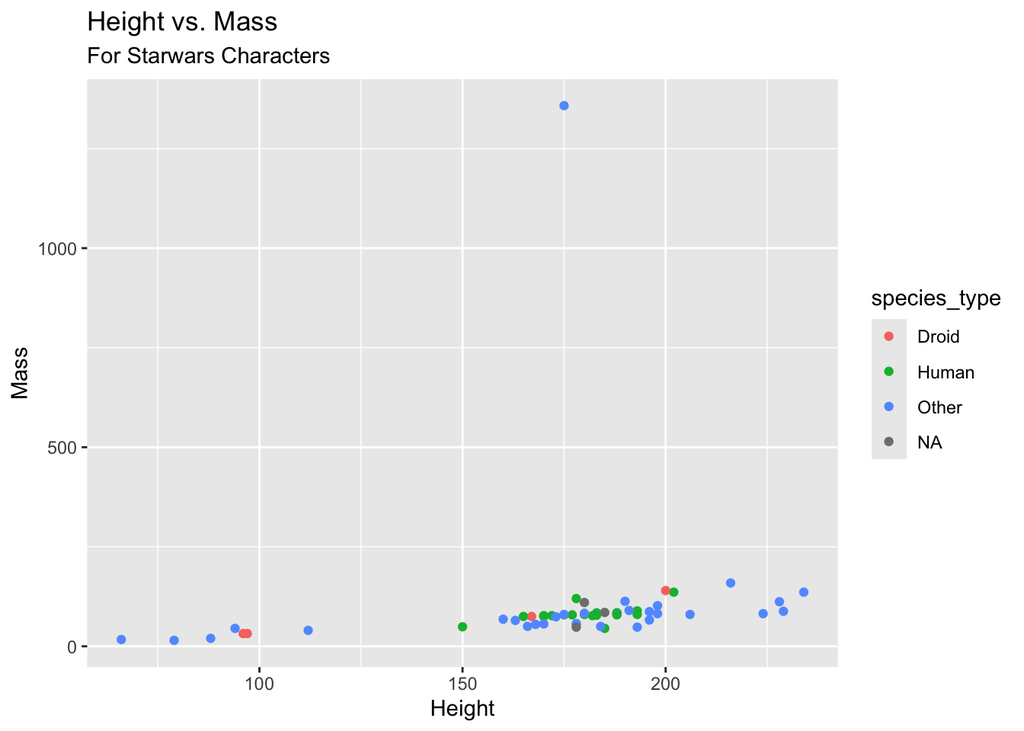

```r
ggplot(starwars) + geom_point(mapping = aes(y = mass, x = height, color = species_type)) + labs(title = "Height vs. Mass", subtitle = "For Starwars Characters", x = "Height", y = "Mass")
```

Note: The variable you create can be your own creation, or you can pick from one of the examples below. You do not need to use `tidyverse`/`dplyr` to create the new variable (although that is encouraged), you can use any techniques from the course.

- TRUE/FALSE: is this character in “A New Hope”
- Is this character a human, Droid, or other.
- TRUE/FALSE: Does this character know Padme?
- Has this character ridden in the Millennium Falcon?

Download the “beautifulThings.txt” file from Canvas (under Datasets). This file contains the lyrics to Benson Boone’s song “Beautiful Things”. Each line in the text file is a line from the song, in order.

3. (2 pts) Create a frequency table of word counts from Beautiful Things. Do not count words that end with commas or question marks as different. For example, “gone” and “gone?” should both be counted as “gone”. Organize it from most frequent to least frequent. Display the top 10 most common words.

```r
library(wordcloud)
boone = "~/Downloads/beautifulThings.txt"
all <- readLines(boone, warn = FALSE)
all <- paste(all, collapse = " ")
all <- tolower(all)
all <- gsub("[[:punct:]]", "", all)
all <- gsub("[[:space:]]", " ", all)

BeautifulThings <- strsplit(all, " ")

wc <- table(BeautifulThings)
wc <- sort(wc, decreasing = T)
head(wc, 10)
```

```
## BeautifulThings
##    i  you  and  ive   oh  got  but dont  god   my
##   24   11    9    8    8    7    5    5    5    5
```

4. (1.5 pts) Look up the help file for the `wordcloud` function. Create a word cloud for the data in the previous question that colors the words into two different colors.

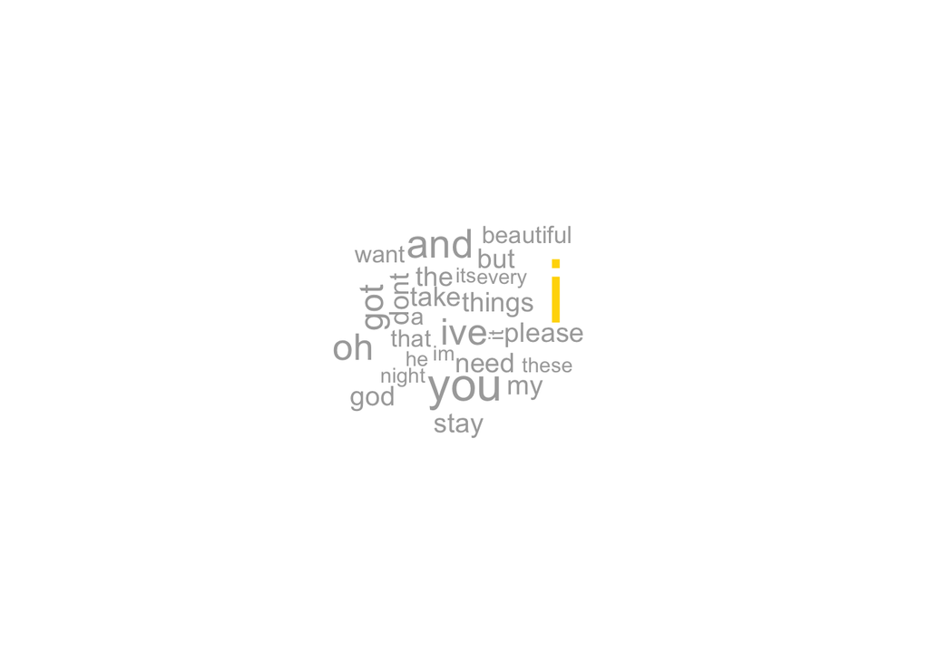

```r
help("wordcloud")
wordcloud(words = names(wc), freq = wc, colors = c("darkgrey", "gold"))
```